# 67364 Project 1 -Telling a Story with Data

Team: 02

Team Members: Chelsea Cui, Shiqi Chou

Topic: Insight of Cultural Differences through Youtube Trending Videos

Source: https://www.kaggle.com/datasnaek/youtube-new

Description Link: https://drive.google.com/drive/folders/1qEg4Giomnrcmtz6YLMfeRo85y7GuNr75

[figure not shown]

## Introduction

Launched since 2005, YouTube has recently become one of the most popular video-sharing platforms across the world. Nowadays, no matter where you are, as long as you have a device that can be connected to the internet, you can have a great time with YouTube.

Behind the great business value of the company, however, the big data created by millions of users are also extremely valuable. Since video watching has become one crucial part of the modern lifestyle, the wacthing habits of people can reflect a lot about how people think and what do they do. Even their culture.

Is there certain category of videos people prefer to see? Do people tend to watch Youtube during weekends or weekdays? Is there a correlation between people's different watching habits and different cultural backgrounds they have? In other words, are there any kinds of videos that are easier to become popular in US as compared to other countries?

In this project, we will take a insight of the cultural differences using trending YouTube video statistics such as views, likes, comments,average trending time of popular videos in Youtube, and tried to reveal people's video-watching preferences based on their locations.

#### What videos are considered as "trending"?

According to [Variety Magazine](http://variety.com/2017/digital/news/youtube-2017-top-trending-videos-music-videos-1202631416/), To determine the year’s top-trending videos, YouTube uses a combination of factors including measuring users interactions (number of views, shares, comments and likes). Note that they’re not the most-viewed videos overall for the calendar year. The final top 10 trending-videos list is ranked by views.

To show how trending videos are calculated, we took a random sample of 30 trending videos from US dataset and normalized the four statistics (numbers of views, likes, comments and dislikes) to calculate the percentage each number takes for the trendingness calculation.

```python
from wordcloud import WordCloud # Need: pip install wordcloud/ pip3 install wordcloud
from operator import itemgetter
import pandas as pd
import matplotlib.pyplot as plt
import seaborn as sns
import numpy as np
import string
import random
import csv

%matplotlib inline
```

```python
# Importing Data

US = pd.read_csv('./data/USvideos.csv') # USA
CA = pd.read_csv('./data/CAvideos.csv') # Canada
GB = pd.read_csv('./data/GBvideos.csv') # Great Britain

US['country'] = "US"
CA['country'] = "CA"
GB['country'] = "GB"
```

```python
random.seed(4)
us_sample_index = [random.randint(1,len(US))for i in range(30)]
sample_us = US.loc[us_sample_index]
us_views_sum = sample_us["views"].sum()
us_likes_sum = sample_us["likes"].sum()
us_dislikes_sum = sample_us["dislikes"].sum()
us_comments_sum = sample_us["comment_count"].sum()

sample_us["views_pct"] = sample_us["views"]/us_views_sum * 1000
sample_us["likes_pct"] = sample_us["likes"]/us_likes_sum * 1000
sample_us["dislikes_pct"] = sample_us["dislikes"]/us_dislikes_sum * 1000
sample_us["comment_pct"] = sample_us["comment_count"]/us_comments_sum *1000

sample_us["xviews_pct"] = (sample_us["views"]/us_views_sum * 1000)/(sample_us["views_pct"] +sample_us["likes_pct"] + sample_us["dislikes_pct"] + sample_us["comment_pct"] )
sample_us["xlikes_pct"] = (sample_us["likes"]/us_likes_sum * 1000)/(sample_us["views_pct"] +sample_us["likes_pct"] + sample_us["dislikes_pct"] + sample_us["comment_pct"] )
sample_us["xdislikes_pct"] = (sample_us["dislikes"]/us_dislikes_sum * 1000)/(sample_us["views_pct"] +sample_us["likes_pct"] + sample_us["dislikes_pct"] + sample_us["comment_pct"] )
sample_us["xcomment_pct"] = (sample_us["comment_count"]/us_comments_sum *1000)/(sample_us["views_pct"] +sample_us["likes_pct"] + sample_us["dislikes_pct"] + sample_us["comment_pct"] )
```

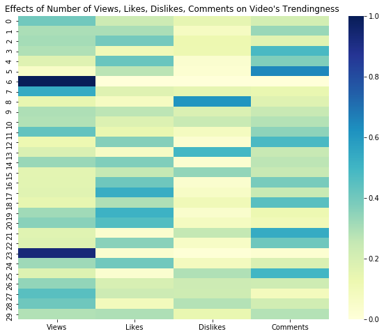

```python
plt.figure(figsize = (10,8))
views_df = pd.DataFrame(sample_us, columns=["xviews_pct",'xlikes_pct',"xdislikes_pct",'xcomment_pct'])
views_df.columns = ["Views","Likes","Dislikes","Comments"]
views_df.index = [str(i) for i in range(30)]
fig = sns.heatmap(views_df, cmap="YlGnBu").set_title('Effects of Number of Views, Likes, Dislikes, Comments on Video\'s Trendingness ')
```

From the heatmap above, we can see that trendingness of videos are not always determined by any single factor but a combination of all four statistics. For example, the 6th video were determined as trending beacuase of its large number of views, while the 16th videos were chosen for its large number of likes.

## Data

Source: https://www.kaggle.com/datasnaek/youtube-new

Collected through YouTube API, the dataset consists lists of top trending videos in YouTube from five countries, including the United States, Great Britain, Germany, Canada, and France during the period from November 14th 2017 to February 18th 2018. In this project, to remain the language consistency and comparability, we will only invesitage the data from United States, Great Britain and Canada.

Each region’s data is in a seperate table but with the same measurements. There are 16 columns in total in each table including basic and fundamental information of the videos such as title, chanel_title, trending_date, views and likes as well as dislikes. With up to 200 trending videos per day, each table has around 18900 lines of data.

## Methods

(1) Data Selection and Dataframe Construction --> Pandas

(2) Plotting --> Tableau/Seaborn/Pyplot

## Questions

- Q1: How do people's interests change across countries?
- Q2: How do people's watching habits change across countries?
- Q3 : Is social event a significant factor affecting the popularity of videos?

## Assumptions

#### Q1: How do people's interests change across countries?

(1) Due to the closeness of geographical locations and the similar historical backgrounds, we expect that the United States and Canada would be more related in terms of people's interests.

(2) In terms of topics, we expect that sports, food, music and politics might be the most popular ones in all three countries. Furthermore, American people might be more interested in sports than the other two countries, while British people may prefer music videos more.

#### Q2: How do people's watching habits change across countries?

Due to the worldwide popularity of YouTube, we assume that the average times needed for a video to become trending are similar among the three countries. However, videos that match people's interest (see Q1) may take shorter times.

#### Q3 : Is social event a significant factor affecting the popularity of videos?

We expect that social event should be a crucial factor affecting the popularity of videos. For example, the popularity of videos related to Super Bowl should increase during the weeks before and after the Super Bowl weekend.

## Data Analysis

### Step 1: Data Cleansing

The dataset is relatively clean and well organized. However, to do some special calculations, we need to change the data form of several fields.

*First, we modified the tag fields to seperate the tags from long strings into lists.*

```python
def replace_quo (l):
    newl = []
    for item in l:
        item = item.replace('"', '')

        newl.append(item)
    return newl

US["xtags"]= US["tags"].apply(lambda x: x.split("|"))
US["xtags"] = US["xtags"].apply(lambda x: replace_quo(x))

CA["xtags"]= CA["tags"].apply(lambda x: x.split("|"))
CA["xtags"] = CA["xtags"].apply(lambda x: replace_quo(x))

GB["xtags"]= GB["tags"].apply(lambda x: x.split("|"))
GB["xtags"] = GB["xtags"].apply(lambda x: replace_quo(x))
```

```python
US.iloc[1]["xtags"]
```

```
['last week tonight trump presidency',
 'last week tonight donald trump',
 'john oliver trump',
 'donald trump']
```

*Then, we modified the format of dates to fit the pandas datetime standards.*

```python
import datetime

def days_between(d1, d2):
    d1 = datetime.strptime(d1, "%Y-%m-%d")
    d2 = datetime.strptime(d2, "%Y-%m-%d")
    return abs((d2 - d1).days)

US["xtrending_date"] = US["trending_date"].apply(lambda x: "20" + x)
US["xtrending_date"] = US["xtrending_date"].apply(lambda x: x.split("."))
US["xpublish_time"] = US["publish_time"].apply(lambda x: x[0:10].split("-"))
US["xtrending_date"] = US["xtrending_date"].apply(lambda x: datetime.date(int(x[0]),int(x[2]),int(x[1])))
US["xpublish_time"] = US["xpublish_time"].apply(lambda x: datetime.date(int(x[0]),int(x[1]),int(x[2])))


CA["xtrending_date"] = CA["trending_date"].apply(lambda x: "20" + x)
CA["xtrending_date"] = CA["xtrending_date"].apply(lambda x: x.split("."))
CA["xpublish_time"] = CA["publish_time"].apply(lambda x: x[0:10].split("-"))
CA["xtrending_date"] = CA["xtrending_date"].apply(lambda x: datetime.date(int(x[0]),int(x[2]),int(x[1])))
CA["xpublish_time"] = CA["xpublish_time"].apply(lambda x: datetime.date(int(x[0]),int(x[1]),int(x[2])))

GB["xtrending_date"] = GB["trending_date"].apply(lambda x: "20" + x)
GB["xtrending_date"] = GB["xtrending_date"].apply(lambda x: x.split("."))
GB["xpublish_time"] = GB["publish_time"].apply(lambda x: x[0:10].split("-"))
GB["xtrending_date"] = GB["xtrending_date"].apply(lambda x: datetime.date(int(x[0]),int(x[2]),int(x[1])))
GB["xpublish_time"] = GB["xpublish_time"].apply(lambda x: datetime.date(int(x[0]),int(x[1]),int(x[2])))
```

After data cleansing, we created a table combininhg data from all three countries.

```python
all_frames = [US,CA,GB]

Total = pd.concat(all_frames,ignore_index=True)


Total["xtags"]= Total["tags"].apply(lambda x: x.split("|"))
Total["xtags"] = Total["xtags"].apply(lambda x: replace_quo(x))


len(Total)
```

```
56895
```

```python
Total.dtypes
```

```
video_id                  object
trending_date             object
title                     object
channel_title             object
category_id                int64
publish_time              object
tags                      object
views                      int64
likes                      int64
dislikes                   int64
comment_count              int64
thumbnail_link            object
comments_disabled           bool
ratings_disabled            bool
video_error_or_removed      bool
description               object
country                   object
xtags                     object
xtrending_date            object
xpublish_time             object
dtype: object
```

### Step 2: Answer Questoins

### Q1: How do people's interests change across countries?

To answer this question, we first did some analyiss about the popular tags in three countries.

```python
us_all_tags = []

for i in range(len(US)):
    us_all_tags.extend(US.iloc[i]["xtags"])

us_all_tags_dic = dict()

for tag in us_all_tags:
    if tag == "[none]": continue
    if tag not in us_all_tags_dic: us_all_tags_dic[tag] = 1
    else: us_all_tags_dic[tag] +=1
```

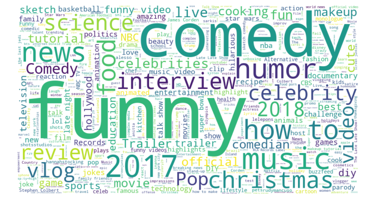

```python
wordcloud = WordCloud(background_color='white',width=900,height=500, max_words=1628,relative_scaling=1,normalize_plurals=False).generate_from_frequencies(us_all_tags_dic)
plt.figure(figsize = (12,10))
plt.imshow(wordcloud, interpolation='bilinear')
plt.axis("off")
plt.show()
```

From the word cloud of popular tags in the U.S., we can see that "comedy", "funny", "music",and "food" videos are very popular.

```python
ca_all_tags = []

for i in range(len(CA)):
    ca_all_tags.extend(CA.iloc[i]["xtags"])

ca_all_tags_dic = dict()

for tag in ca_all_tags:
    if tag == "[none]": continue
    if tag not in ca_all_tags_dic: ca_all_tags_dic[tag] = 1
    else: ca_all_tags_dic[tag] +=1
```

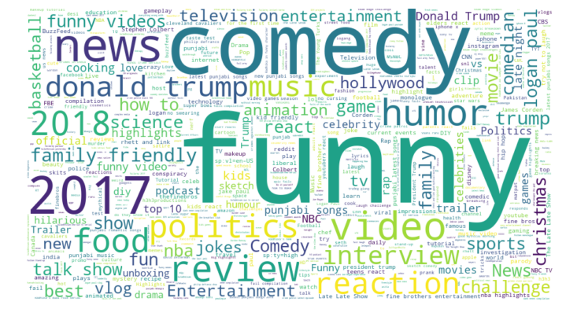

```python
wordcloud = WordCloud(background_color='white',width=900,height=500, max_words=1628,relative_scaling=1,normalize_plurals=False).generate_from_frequencies(ca_all_tags_dic)
plt.figure(figsize = (12,10))
plt.imshow(wordcloud, interpolation='bilinear')
plt.axis("off")
plt.show()
```

In the word cloud of Canada, "funny","comedy" videos are still popular, however, people are also interested in "politics" and "news" a lot.

```python
gb_all_tags = []

for i in range(len(GB)):
    gb_all_tags.extend(GB.iloc[i]["xtags"])

gb_all_tags_dic = dict()

for tag in gb_all_tags:
    if tag == "[none]": continue
    if tag not in gb_all_tags_dic: gb_all_tags_dic[tag] = 1
    else: gb_all_tags_dic[tag] +=1
```

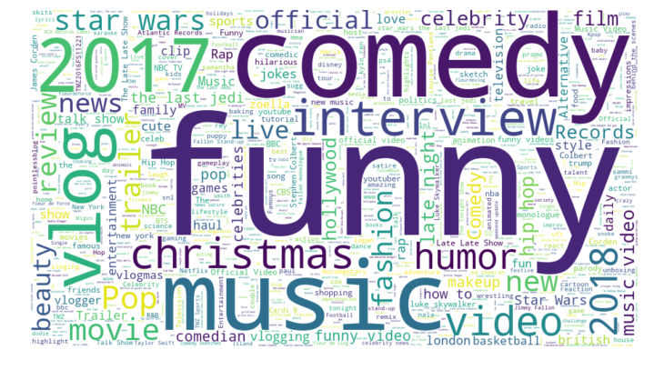

```python
wordcloud = WordCloud(background_color='white',width=900,height=500, max_words=1628,relative_scaling=1,normalize_plurals=False).generate_from_frequencies(gb_all_tags_dic)
plt.figure(figsize = (12,10))
plt.imshow(wordcloud, interpolation='bilinear')
plt.axis("off")
plt.show()
```

In the Great Britain, besides "funny" and "comedy" videos, people also like fashion videos which are about "music" and "vlog".

```python
all_tags = []

for i in range(len(Total)):
    all_tags.extend(Total.iloc[i]["xtags"])

all_tags_dic = dict()

for tag in all_tags:
    if tag == "[none]": continue
    if tag not in all_tags_dic: all_tags_dic[tag] = 1
    else: all_tags_dic[tag] +=1
```

```python
sorted_all = sorted([(value,key) for (key,value) in all_tags_dic.items()],reverse=True)
top_50 = sorted_all[:10]
```

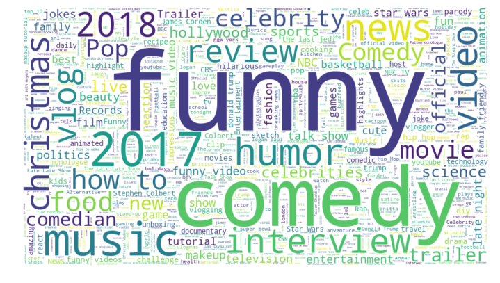

```python
wordcloud = WordCloud(background_color='white',width=900,height=500, max_words=1628,relative_scaling=1,normalize_plurals=False).generate_from_frequencies(all_tags_dic)
plt.figure(figsize = (12,10))
plt.imshow(wordcloud, interpolation='bilinear')
plt.axis("off")
plt.show()
```

From the combined word cloud, we can see that most highly ranked tags are popular across countries.

```python
US_top50 = []
CA_top50 = []
GB_top50 = []


for tag in top_50:
    word = tag[1]
    if word in us_all_tags_dic.keys():
        US_top50.append((word,us_all_tags_dic[word],'US'))
    else: US_top50.append((word,0,'US'))

    if word in ca_all_tags_dic.keys():
        CA_top50.append((word,ca_all_tags_dic[word],'CA'))
    else: CA_top50.append((word,0,'CA'))

    if word in gb_all_tags_dic.keys():
        GB_top50.append((word,gb_all_tags_dic[word],'GB'))
    else: GB_top50.append((word,0,'GB'))
```

```python
Total_50 = US_top50 + CA_top50 + GB_top50
Total_50_df = pd.DataFrame(Total_50, columns=['tag','count','country'])
```

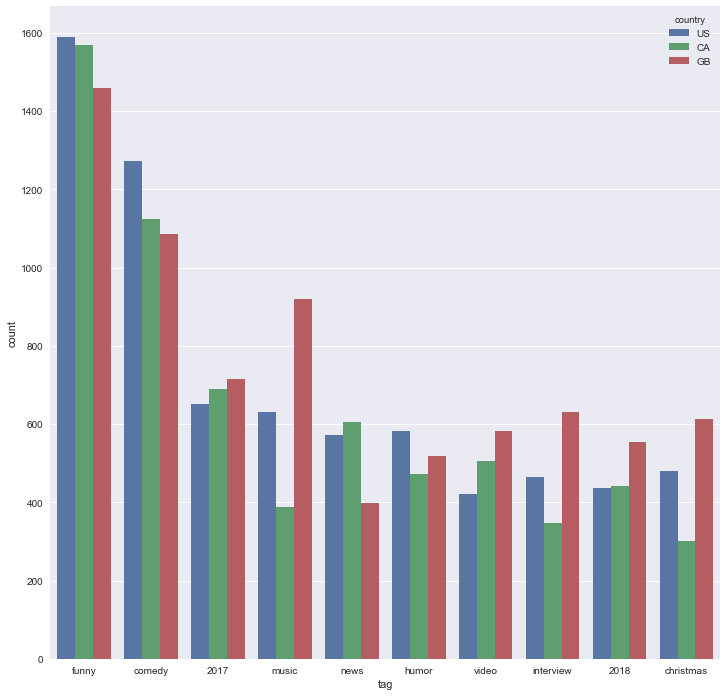

```python
plt.figure(figsize = (12,12))
sns.set(style="darkgrid")
ax = sns.barplot(x="tag", y="count",hue="country", data=Total_50_df)
```

We also found the top10 most popular tags cross the three countries. From this plot, we can see that, despite of the similar general trend, there are some minor preferences belonging to specific countries. For example, British people are big fans of music, while Canadian people prefer news more than the otehr two countries.

```python
US_dup_removed = US.drop_duplicates(subset='video_id', keep="first")
us_channels = US_dup_removed["channel_title"].value_counts()
us_top20_channels = us_channels.sort_values(ascending=False)[0:20]
us_top10_channels = us_channels.sort_values(ascending=False)[0:10]
#us_top20_channels.to_csv("us_channels_count.csv")
```

Besides tags, we also analyzed the popular video channels in the three countries.

[figure not shown]

```python
GB_dup_removed = GB.drop_duplicates(subset='video_id', keep="first")
gb_channels = GB_dup_removed["channel_title"].value_counts()
gb_top20_channels = gb_channels.sort_values(ascending=False)[0:20]
gb_top10_channels = gb_channels.sort_values(ascending=False)[0:10]
#gb_top20_channels.to_csv("gb_channels_count.csv")
```

[figure not shown]

```python
CA_dup_removed = CA.drop_duplicates(subset='video_id', keep="first")
ca_channels = CA_dup_removed["channel_title"].value_counts()
ca_top20_channels = ca_channels.sort_values(ascending=False)[0:20]
ca_top10_channels = ca_channels.sort_values(ascending=False)[0:10]
#ca_top20_channels.to_csv("ca_channels_count.csv")
```

[figure not shown]

In general, in terms of channels, American and British people prefer talk shows and sports shows, while Canadian people love drama better.

### Q2: How do people's watching habits change across countries?

To answer this question, we first investigated when do people watch videos throughout the week.

```python
top_10_channels = [us_top10_channels,ca_top10_channels,gb_top10_channels]

def top10_views_times(country):
    c_top10 = []
    c = all_frames[country]
    c_channels = top_10_channels[country]
    for i in range(10):
        temp = c[c["channel_title"] == c_channels.index[i]].drop_duplicates(subset='video_id', keep="last").sort_values(by=['views'])[0:5]
        c_top10.append(temp)

    l=[]
    for channel in c_top10:
        for i in range(5):
            channel_title = channel['channel_title'].tolist()
            views = channel['views'].tolist()
            date = channel['xtrending_date'].tolist()
        temp = pd.DataFrame({'Channel':channel_title,'Views':views, 'Date':date})
        l.append(temp)

    return pd.concat(l,ignore_index=True)

us_top10_views = top10_views_times(0)
ca_top10_views = top10_views_times(1)
gb_top10_views = top10_views_times(2)
```

```python
#us_top10_views.to_csv('us_top10_views.csv')
#gb_top10_views.to_csv('gb_top10_views.csv')
#ca_top10_views.to_csv('ca_top10_views.csv')
```

[figure not shown]

We found that, American people prefer to watch videos during the weekends, while British people prefer to watch videos during the weekdays. And there is no specific trend for Canada.

```python
start_date = datetime.datetime.strptime("2017-11-14","%Y-%m-%d") # we start counting weeks from this day

US["diff_in_days"] = abs(US["xtrending_date"]-US["xpublish_time"])
US["days_between"] = US["xtrending_date"].apply(lambda x: datetime.date.isoformat(x))
US["days_between"] = US["days_between"].apply(lambda x: datetime.datetime.strptime(x, "%Y-%m-%d"))
US["days_between"] = US["days_between"].apply(lambda x: (x - start_date).days)
US["week_num"] = US["days_between"].apply(lambda x: x//7+1)
US["diff_in_days_int"] = US["diff_in_days"].apply(lambda x: x.days)

US["diff_in_days_int"].sum()/US["video_id"].count()
```

```
26.514626047541242
```

```python
CA["days_between"] = CA["xtrending_date"].apply(lambda x: datetime.date.isoformat(x))
CA["days_between"] = CA["days_between"].apply(lambda x: datetime.datetime.strptime(x, "%Y-%m-%d"))
CA["days_between"] = CA["days_between"].apply(lambda x: (x - start_date).days)
CA["week_num"] = CA["days_between"].apply(lambda x: x//7+1)
CA["diff_in_days"] = abs(CA["xtrending_date"]-CA["xpublish_time"])
CA["diff_in_days_int"] = CA["diff_in_days"].apply(lambda x: x.days)
CA["diff_in_days_int"].sum()/CA["video_id"].count()
```

```
5.340688344594595
```

```python
GB["diff_in_days"] = abs(GB["xtrending_date"]-GB["xpublish_time"])
GB["days_between"] = GB["xtrending_date"].apply(lambda x: datetime.date.isoformat(x))
GB["days_between"] = GB["days_between"].apply(lambda x: datetime.datetime.strptime(x, "%Y-%m-%d"))
GB["days_between"] = GB["days_between"].apply(lambda x: (x - start_date).days)
GB["week_num"] = GB["days_between"].apply(lambda x: x//7+1)
GB["diff_in_days"] = abs(GB["xtrending_date"]-GB["xpublish_time"])
GB["diff_in_days_int"] = GB["diff_in_days"].apply(lambda x: x.days)
GB["diff_in_days_int"].sum()/GB["video_id"].count()
```

```
57.10823058278006
```

Second, we analyzed the average trending time of videos across countries.

[figure not shown]

```python
uni_US = US.drop_duplicates("video_id", keep="first")
uni_CA = CA.drop_duplicates("video_id", keep="first")
uni_GB = GB.drop_duplicates("video_id", keep="first")
US_CA_GB = uni_US.merge(uni_CA, how='inner', right_on=['video_id', 'xpublish_time'], left_on=['video_id', 'xpublish_time']).merge(uni_GB, how='inner', right_on=['video_id','xpublish_time'], left_on=['video_id','xpublish_time'])
US_CA_GB["US_CA_diff"] = abs(US_CA_GB["xtrending_date_x"]-US_CA_GB["xtrending_date_y"])
US_CA_GB["US_GB_diff"] = abs(US_CA_GB["xtrending_date_x"]-US_CA_GB["xtrending_date"])
US_CA_GB["CA_GB_diff"] = abs(US_CA_GB["xtrending_date_y"]-US_CA_GB["xtrending_date"])
sorted_US_CA_GB = US_CA_GB.sort_values(by=["US_GB_diff"], ascending = False)

sorted_US_CA_GB.head()
```

|  | video_id | trending_date_x | title_x | channel_title_x | category_id_x | publish_time_x | tags_x | views_x | likes_x | dislikes_x | ... | country | xtags | xtrending_date | diff_in_days | days_between | week_num | diff_in_days_int | US_CA_diff | US_GB_diff | CA_GB_diff |
| --- | --- | --- | --- | --- | --- | --- | --- | --- | --- | --- | --- | --- | --- | --- | --- | --- | --- | --- | --- | --- | --- |
| 197 | TnCa71iUVxA | 18.18.01 | Maroon 5 - Wait | Maroon5VEVO | 10 | 2018-01-17T17:00:03.000Z | Maroon\|"Wait"\|"222"\|"Records/Interscope"\|"Reco... | 692807 | 70211 | 2689 | ... | GB | [Maroon, Wait, 222, Records/Interscope, Record... | 2018-02-06 | 20 days | 84 | 13 | 20 | 0 days | 19 days | 19 days |
| 20 | TyHvyGVs42U | 17.17.11 | Luis Fonsi, Demi Lovato - Échame La Culpa | LuisFonsiVEVO | 10 | 2017-11-17T05:00:01.000Z | Luis\|"Fonsi"\|"Demi"\|"Lovato"\|"Échame"\|"La"\|"Cu... | 499946 | 135292 | 3528 | ... | GB | [Luis, Fonsi, Demi, Lovato, Échame, La, Culpa,... | 2017-12-01 | 14 days | 17 | 3 | 14 | 1 days | 14 days | 13 days |
| 173 | PmUL6wMpMWw | 18.09.01 | Red Sparrow \| Official Trailer [HD] \| 20th Cen... | 20th Century Fox | 1 | 2018-01-08T14:00:11.000Z | Trailer\|"Jennifer Lawrence"\|"Joel Edgerton"\|"M... | 1711525 | 7716 | 728 | ... | GB | [Trailer, Jennifer Lawrence, Joel Edgerton, Ma... | 2018-01-21 | 13 days | 68 | 10 | 13 | 0 days | 12 days | 12 days |
| 248 | 6OcOO1k-vGE | 18.30.01 | Bruno Mars and Cardi B - Finesse (LIVE From Th... | Vevo | 10 | 2018-01-29T09:49:15.000Z | Bruno Mars and Cardi B Finesse R&B | 4866576 | 185646 | 5306 | ... | GB | [Bruno Mars and Cardi B Finesse R&B] | 2018-02-09 | 11 days | 87 | 13 | 11 | 0 days | 10 days | 10 days |
| 147 | d1hs-JI_yBE | 17.22.12 | Kobe Bryant No.8 & No.24 Jersey Retirement In ... | NBA | 17 | 2017-12-19T06:04:49.000Z | nba\|"highlights"\|"basketball"\|"plays"\|"amazing... | 660364 | 13832 | 224 | ... | GB | [nba, highlights, basketball, plays, amazing, ... | 2017-12-28 | 9 days | 44 | 7 | 9 | 2 days | 6 days | 8 days |

5 rows × 71 columns

By scanning the overlapping trending videos, we chose the official [Trailer of Red Sparrow](https://www.youtube.com/watch?v=PmUL6wMpMWw) and [Kobe Bryant No.8 & No.24 Jersey Retirement In Los Angeles](https://www.youtube.com/watch?v=d1hs-JI_yBE) as two illustrating examples.

### Case Study 1 - Trailer of Red Sparrow

```python
v1_vid = "PmUL6wMpMWw"
```

```python
def views_per_day_correct(l):
    if len(l) <= 1: return l
    res = [0]*len(l)
    res[0] = l[0]
    for i in range(1,len(l)):
        res[i] = l[i] - l[i-1]

    return res

def views_per_day(vid,country):
    c = all_frames[country]
    v = c[c['video_id'] == vid]
    v_trend_times = v["views"].tolist()
    v_trend_times_corr = views_per_day_correct(v_trend_times)

    return v_trend_times_corr
```

```python
v1_us_df = pd.DataFrame({'trending_date':(US[US["video_id"] == v1_vid]["xtrending_date"].tolist()),'Views':views_per_day(v1_vid,0)})
v1_us_df["Country"] = "US"

v1_gb_df = pd.DataFrame({'trending_date':(GB[GB["video_id"] == v1_vid]["xtrending_date"].tolist()),'Views':views_per_day(v1_vid,2)})
v1_gb_df["Country"] = "GB"

v1_ca_df = pd.DataFrame({'trending_date':(CA[CA["video_id"] == v1_vid]["xtrending_date"].tolist()),'Views':views_per_day(v1_vid,1)})
v1_ca_df["Country"] = "CA"

v1_views_df = pd.concat([v1_us_df,v1_ca_df,v1_gb_df],ignore_index=True)

#v1_views_df.to_csv("v1_veiws.csv")
```

[figure not shown]

From the case study, we found that the Red Sparrow Trailer was taking way more time to become popular in the Great Britain (13 days) than in U.S. and Canada (1 day). We think it's probably related to the location, because the movie was first releasd in the states and then to Europe.

However, by scanning the total number of views and likes of the video, we found that, even though it took longer times to become trending, the Trailer is favored the most by British people, as they generally have more responses, such as comments and likes, than the other two countries.

### Case Study 2 - Kobe Bryant No.8 & No.24 Jersey Retirement In Los Angeles

```python
v2_vid = "d1hs-JI_yBE"
```

```python
v2_us_df = pd.DataFrame({'trending_date':(US[US["video_id"] == v2_vid]["xtrending_date"].tolist()),'Views':views_per_day(v2_vid,0)})
v2_us_df["Country"] = "US"

v2_gb_df = pd.DataFrame({'trending_date':(GB[GB["video_id"] == v2_vid]["xtrending_date"].tolist()),'Views':views_per_day(v2_vid,2)})
v2_gb_df["Country"] = "GB"

v2_ca_df = pd.DataFrame({'trending_date':(CA[CA["video_id"] == v2_vid]["xtrending_date"].tolist()),'Views':views_per_day(v2_vid,1)})
v2_ca_df["Country"] = "CA"

v2_views_df = pd.concat([v2_us_df,v2_ca_df,v2_gb_df],ignore_index=True)

#v2_views_df.to_csv("v2_veiws.csv")
```

[figure not shown]

The result of the second case study is quite similar to the first one. As the video took only 1 and 3 days respectively to become popular in Canada and U.S., but 9 days in the Great Britain.

When we compare the the total number of views and likes of the video, however, there was no significant difference among the three countries. Even though it took longer time to be trending, the video is still favored by British People.

Thus, we conclude that, the time it takes for a video to be trending is not related to how people like the video but the watching habits of the audiences. In general, videos are more likely to become viral in the U.S. and Canada than in the Great Britain.

### Q3 : Is social event a significant factor affecting the popularity of videos?

To answer this question, we created a map of popular words in video titles and selected three most representative words to see the trend variations during the 4 months.

```python
import string
from operator import itemgetter
exclude = set(string.punctuation)

def get_rid_of_punctuations(s):
    result = ""
    for ch in s:
        if ch not in exclude:
            result = result + ch
    return result

def get_word_map(data):
    word_map = dict()
    for each in data["title"]:
        for word in each.split():
            w = get_rid_of_punctuations(word)
            if w in word_map: word_map[w] = word_map[w] + 1
            else: word_map[w] = 0
    return word_map

US_word_map = get_word_map(US)
US_sorted_word_map = sorted(US_word_map.items(), key=itemgetter(1), reverse = True)

CA_word_map = get_word_map(CA)
CA_sorted_word_map = sorted(CA_word_map.items(), key=itemgetter(1), reverse = True)

GB_word_map = get_word_map(GB)
GB_sorted_word_map = sorted(GB_word_map.items(), key=itemgetter(1), reverse = True)

us = [US_sorted_word_map[i][0] for i in range(200)]
ca = [CA_sorted_word_map[j][0] for j in range(200)]
gb = [GB_sorted_word_map[k][0] for k in range(200)]
```

```python
## get csv files for analysis

Drama_df = CA.groupby("week_num").apply(lambda x: x['title'].str.contains("Drama").sum()).to_frame()
# Drama_df.to_csv("drama.csv")
Bowl_df = US.groupby("week_num").apply(lambda x: x['title'].str.contains("Bowl").sum()).to_frame()
# Bowl_df.to_csv("bowl.csv")
Harry_df = GB.groupby("week_num").apply(lambda x: x['title'].str.contains("Harry").sum()).to_frame()
# Harry_df.to_csv("harry.csv")
```

[figure not shown]

[figure not shown]

In Canada, however, the word drama has always been popular throught the year.

[figure not shown]

In the Great Britain, the number of videos about "Harry" suddenly increased at the 3rd week, when the British songwriter Harry Styles released his new song-Kiwi.

### Implication

Cultural difference is a crucial factor in Youtube’s video trends. Certain categories of videos are easier to become popular in certain countries. Sports-related videos are favored by people in the US and UK, while TV shows and drama are the kind that is popular in Canada throughout the year. Songs of local songwriters, movies and tv series that try to cater local people’s cultural preferences are not that welcome by international audiences.

Despite differences, there are common video trends in Youtube across all countries we analysed. People watch Youtube for fun ! Videos about music, movies, jokes and humor are the most eye-catching and attracting ones for viewers. Also, people look for news feed and commentary of current hitting topics. Channels like CNN and Washington Post consist of a large part of popular channels and videos of President’s address, reforms, and famous commentators become trending shortly after posts.